# Effect of the Student grade according to Different Variables

## Investigation Overview

In this investigation, I wanted to look on how different conditions affect our students grade and how to apply them. Which can give us a better results for our children, kids, students ..etc. The main focus in this investigation is on the four conditions that affect our students for a better grades in "Math", "Writing", and "Reading" test.

## Dataset Overview

The data consisted of 1,000 student with 8 columns. The attributes that affect the student **Race/Ethnicity**, **Gender**, **Parental level**, **Lunch**, and **Preperation Test** and the outcome of the student grades in "Math", "Reading",and "Writing" test. No data has been removed as their was no null values or duplicates

# Distrubution of our students Tests

In the math test our grades are normally distrubuted and can be clarify not many conditions affect their grades. On the other hand, the **Writing** and **Reading** test has a more spikey values make us wonder why their is **sudden fall** in grades and **how to fix** these problems?.

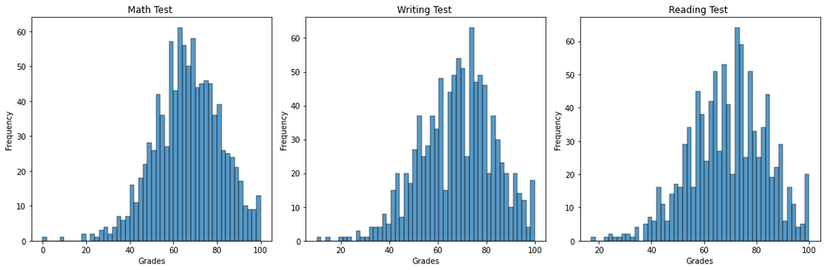

# Effect of taking a preparation test.

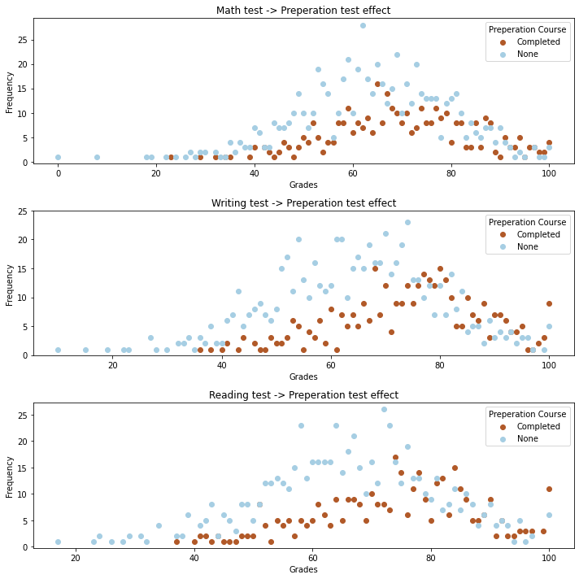

# Effect of gender on the student grades.

According to our figure below:-

- Math test:- **Male** is better than **Female**.
- Reading and Writing:- **Females** are much better than males after 70% as we can see in the figure below the frequancy difference is big.
- Giving that male's needs more care and assiting in their reading and writing skills.

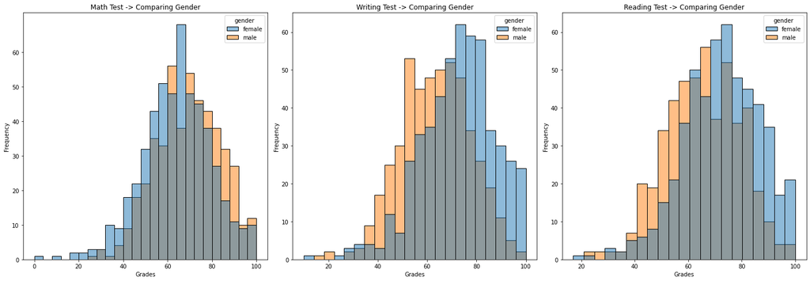

# Let us see the affect of ethinicty/race on grades

There are 5 groups of ethinicity as shown in the figure below, we can say that group A has the lowest grades in the 3 exams. But, we saw a major difference when they taken a preperation test. A major improvement in all test giving us the hint that group A needs our care and giving more attention on their learning syllabus that need to be improved. We conclude that group A has a great potential students, but need a extra care on their school learning system that we need to figure it out.

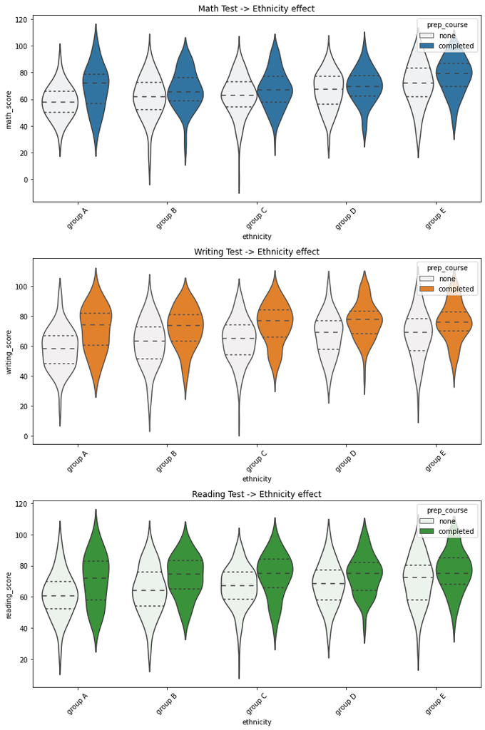